# How to run standard statistics

In the first exercise, you practiced plotting ERPs and many data manipulation commands.

Now we’ll move on to running some straightforward statistics and how to plot those alongside the ERPs.

Remember, help for any command can be looked up using ?command in console, or searching for it in the help pane.

## Packages and commands

You’ll need to load the following packages * tidyverse * afex * broom

We’ll be using the following new commands * group_by() * summarise() * t.test() * aov_ez() * map()/map_dbl()

First, load the packages named above *tidyverse* and *afex*, and reload the data frame you saved from the first exercise using load() or read_csv().

```r
library(tidyverse)
library(afex)
library(broom)
load('../user_data/final_df.RData')
theme_set(theme_classic())
```

## Pre-specified time windows

It’s common to choose, **a priori**, specific time windows for analysis, taking, for example, mean amplitudes over a particular time window.

Let’s start by examining ERPs in the P1 time window. We’ll begin by pretending this isn’t a 2 X 3 design, and doing paired t-tests on mean amplitudes in the time window from approximately 85-135 ms.

Rows from a dataframe can be selected using *filter()*. Filter accepts logical, conditional arguments. For example, filter(Subject == 5) would select only rows from subject 5.

Use filter to select rows where Time >= 85 and Time <= 135. Note that with multiple conditions, you have to specify the full argument (e.g. x > 5 & x < 8; not x > 5 & <8)

*group_by()* is used to group rows together according to the values or levels of the specified column.

*summarise()* is used to create summaries of multiple values.

Assign this to a separate data frame, as we want to keep the original for later analyses.

| Object | stdev | se | amplitude |
| --- | --- | --- | --- |
| Non-Object | 2.398604 | 0.002050089 | 3.347231 |
| Object | 2.446206 | 0.002090775 | 4.197546 |

Before running statistics, let’s do some plots.

Set up a *ggplot()* object for your new dataframe.

e.g.

```
ggplot(new_df, aes(x = Object, y = amplitude))
```

For the purposes of demonstration, let’s start with a bar plot. Note: the purpose of this demonstration is to show that bar plots are bad. We’ll also add 95% confidence intervals.

Add bars using stat_summary(geom = “bar”). Add errorbars using geom = “pointrange”; remember to change fun.data to plot confidence intervals!

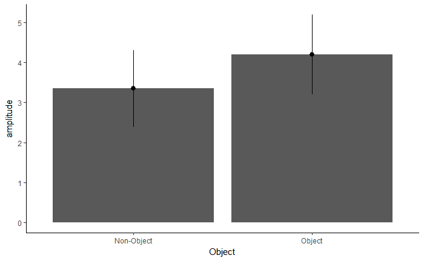

```r
ggplot(obj_pairs, aes(x = Object, y = amplitude)) +
  stat_summary(geom = "bar") +
  stat_summary(fun.data = mean_cl_normal, geom = "pointrange")
```

We can do much better than this. Add individual data points using geom_point(). Remember: each layer of the plot is drawn consecutively.

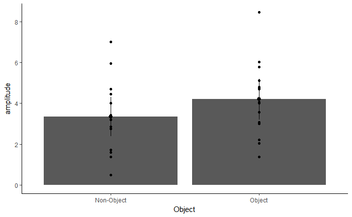

```r
ggplot(obj_pairs, aes(x = Object, y = amplitude)) +
  stat_summary(geom = "bar") +
  geom_point() +
  stat_summary(fun.data = mean_cl_normal, geom = "pointrange")
```

Let’s ditch the bars entirely and add lines connecting the datapoints from within each subject, so that we can see the trend for each subject.

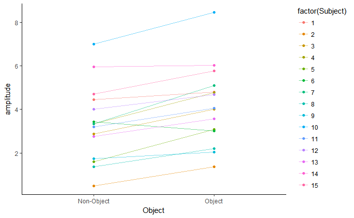

```r
ggplot(obj_pairs, aes(x = Object, y = amplitude, colour = factor(Subject))) +
  geom_point() +
  geom_line(aes(group = Subject), alpha = 0.5)
```

This looks like Object amplitudes are overall higher, although the distributions substantially overlap. The direction is mostly consistent across subjects, with only one person going in the opposite direction.

Let’s go ahead with our paired t-test using the *t.test()* command.

*t.test()* can be used with typical R modelling syntax:

```
dv ~ iv
```

In R, ~ used in a formula usually means “modelled by”. In this case we want to model amplitude by Object. Make sure you `paired = TRUE` to indicate that this is a **paired**, dependent t-test. Allocate the result to a variable using *<-*

```r
test_result <- t.test(amplitude~Object, data = obj_pairs, paired = TRUE)
test_result
```

```
    Paired t-test

data:  amplitude by Object
t = -5.6145, df = 14, p-value = 6.38e-05
alternative hypothesis: true difference in means is not equal to 0
95 percent confidence interval:
 -1.1751415 -0.5254875
sample estimates:
mean of the differences
             -0.8503145
```

The resulting variable is a list object with individual elements that can be accessed using the $ operator or [] subsetting. For example, if you stored the output of t-test in a variable called test_result, you could get the p-value as follows:

```
test_result$p.value
test_result[3]
```

```r
test_result[[3]]
```

```
[1] 6.38018e-05
```

Helpfully, the output of many stats objects can be tidied up and turned into a dataframe using *tidy* from the *broom* package, which makes them easier to use for subsequent plotting (see next section). Try that now

```r
broom::tidy(test_result)
```

| estimate | statistic | p.value | parameter | conf.low | conf.high | method | alternative |
| --- | --- | --- | --- | --- | --- | --- | --- |
| -0.8503145 | -5.614507 | 6.38018e-05 | 14 | -1.175142 | -0.5254875 | Paired t-test | two.sided |

[output not shown]

[output cut: 80 more lines]

```r
summarySEwithin(hmm, idvar = "Subject", withinvars = c("Object","Frequency"), measurevar = "amplitude")
```

```
Automatically converting the following non-factors to factors: Object, Frequency
```

| Object | Frequency | N | amplitude | sd | se | ci |
| --- | --- | --- | --- | --- | --- | --- |
| Non-Object | BB | 15 | 4.084713 | 0.9721028 | 0.2509959 | 0.5383326 |
| Non-Object | HSF | 15 | 3.008859 | 0.8984719 | 0.2319845 | 0.4975572 |
| Non-Object | LSF | 15 | 2.948121 | 0.7818935 | 0.2018840 | 0.4329982 |
| Object | BB | 15 | 4.761815 | 0.9721659 | 0.2510122 | 0.5383675 |
| Object | HSF | 15 | 4.348576 | 0.5154091 | 0.1330781 | 0.2854240 |
| Object | LSF | 15 | 3.482245 | 0.7908267 | 0.2041906 | 0.4379452 |

```r
all_pairs <- final_df %>%
  filter(Time >= 85 & Time <= 135) %>%
  group_by(Subject,Object, `Spatial Frequency`) %>%
  rename(Frequency = `Spatial Frequency`) %>%
  summarise(amplitude = mean(amplitude))
```

[output not shown]

### Mass univariate tests

Often we want to run a whole series of tests across multiple timepoints, electrodes, frequency bands etc. Use the *nest()* function to create a nested data frame.

```r
time_nest <- nest(final_df, -Time)
head(time_nest)
```

[output not shown]

Why is this useful? This makes it simple iterate through each timepoint using **map** commands from *purrr*. Map command (map, map_dbl, map_df) take a list as input and perform a function on each element of that list. We’ll add an extra column to our nested data frame containing the output of the t.test() function applied to each element of the *data* list within the time_nest frame.

```r
time_nest <- mutate(time_nest,
                    stats = map(data, ~t.test(amplitude ~ Object,
                                              paired = TRUE, data = .x)))
head(time_nest)
```

[output not shown]

We now have a data frame with the results of the t.test function for each timepoint. Suppose you now want to retrieve the t.test results for a specific timepoint. You can access list elements using double brackets [[]]; you would need to find the right row number for the timepoint you want, and enclose that in the brackets.

```r
time_nest$stats[[10]]
```

[output not shown]

Alternatively, we can use map to iterate through the list and extract, for example, each p-value.

```r
time_nest %>%
  mutate(pvals = map_dbl(stats, "p.value"))
```

[output not shown]

Alternatively, we can use broom::tidy() to convert our statistical test results into a one-line data frame. Then we remove the original data using select() and unnest() to get back a data frame with a column for each element of the statistical test.

```r
stat_out <- levCatGA %>%
  nest(-Time) %>%
  mutate(stats = (map(data, ~broom::tidy(t.test(amplitude~Category, paired = TRUE, data = .x))))) %>%
  select(-data) %>%
  unnest()
```

### Difference waves

A very useful tool when plotting ERPs is the difference wave. It’s simpler to subtract two columns from each other than it is to subtract groups of rows from a single column. Thus, we need to make our data wide again.

We can use spread() for this. It is the opposite of gather() and has the same syntax.

To make this a little more interesting, let’s try out pipes (*%>%*) and *mutate()*.

Pipe the output from *spread()* down to text line and use *mutate()* to create a new variable - the difference between objects and non-objects.

Assign it to a new data frame.

```
difference_df <- spread(final_df, Object, amplitude) %>%
  mutate(difference = Object - `Non-Object`)

head(difference_df)
```

```r
difference_df <- spread(difference_df, Object, amplitude) %>%
  mutate(difference = Object - `Non-Object`)

head(difference_df)
```

[output not shown]

The data frame now has the difference between objects and non-objects for each level of spatial frequency.

Create an ERP plot facetted on Spatial Frequency to plot the difference between objects and non-objects in for each level of spatial frequency. Instead of using, *facet_wrap()*, try using *facet_grid()*. This will allow you to stack the facets vertically by using the following

facet_grid(varname ~ .)

Add confidence intervals as above.

```r
difference_df %>%
  ggplot(aes(x = Time, y = difference, fill = `Spatial Frequency`)) +
  stat_summary(fun.data = mean_cl_normal, geom = "ribbon", alpha = 0.2)+
  stat_summary(fun.y = mean, geom = "line") +
  facet_grid(`Spatial Frequency`~.)
```

[output not shown]